# Open Project - Bayesian Clustering

The authors of this work are:

- Ion Bueno Ulacia, 100364530
- Daniel Martín Cruz, 100384121

We will start by importing the libraries we will need for the development of this project. These libraries are `BayesLCA` for the analysis and `tidyverse` for the dataset manipulation.

```r
library(BayesLCA)
library(tidyverse)
```

## Description of the data set

This dataset was submitted by the *Teaching of Statistics in the Health Sciencies (TSHS)* to Kaggle and can be found in this [link](https://www.kaggle.com/omnamahshivai/surgical-dataset-binary-classification). We can found information about surgeries, here is a summary of the columns:

```r
surgery = read.csv('Surgical-deepnet.csv')
attach(surgery)
head(surgery)
```

```
##     bmi  Age asa_status baseline_cancer baseline_charlson baseline_cvd
## 1 19.31 59.2          1               1                 0            0
## 2 18.73 59.1          0               0                 0            0
## 3 21.85 59.0          0               0                 0            0
## 4 18.49 59.0          1               0                 1            0
## 5 19.70 59.0          1               0                 0            0
## 6 20.24 59.0          0               1                 0            0
##   baseline_dementia baseline_diabetes baseline_digestive baseline_osteoart
## 1                 0                 0                  0                 0
## 2                 0                 0                  0                 0
## 3                 0                 0                  0                 0
## 4                 0                 1                  1                 0
## 5                 0                 0                  0                 0
## 6                 0                 0                  0                 0
##   baseline_psych baseline_pulmonary ahrq_ccs ccsComplicationRate ccsMort30Rate
```

[output cut: 20 more lines]

In this project, the technique chosen to practice is *Bayesian Clustering*. That is why we will remove all the non-binary variables from this dataset.

```r
surgery = surgery %>% select(gender, baseline_cancer, baseline_cvd, baseline_dementia,
                             baseline_diabetes, baseline_digestive, baseline_osteoart,
                             baseline_psych,  baseline_pulmonary, mort30, complication)
```

By doing this we keep:

- **gender:** in the data dictionary provided by the TSHS, we have that $gender=1$ corresponds to male and $gender=2$ corresponds to female. In the dataset we observe that this variable only takes 0 and 1 as values. We will assume that $gender=0$ corresponds to male and $gender=1$ corresponds to female gender.
- **baseline_disease:** indicates the presence of the disease in person being operated.
- **mort30:** 30-day mortality.
- **complication:** in-Hospital complication.

## Analysis

It is always advisable to start by showing some visualization before diving into the analysis.

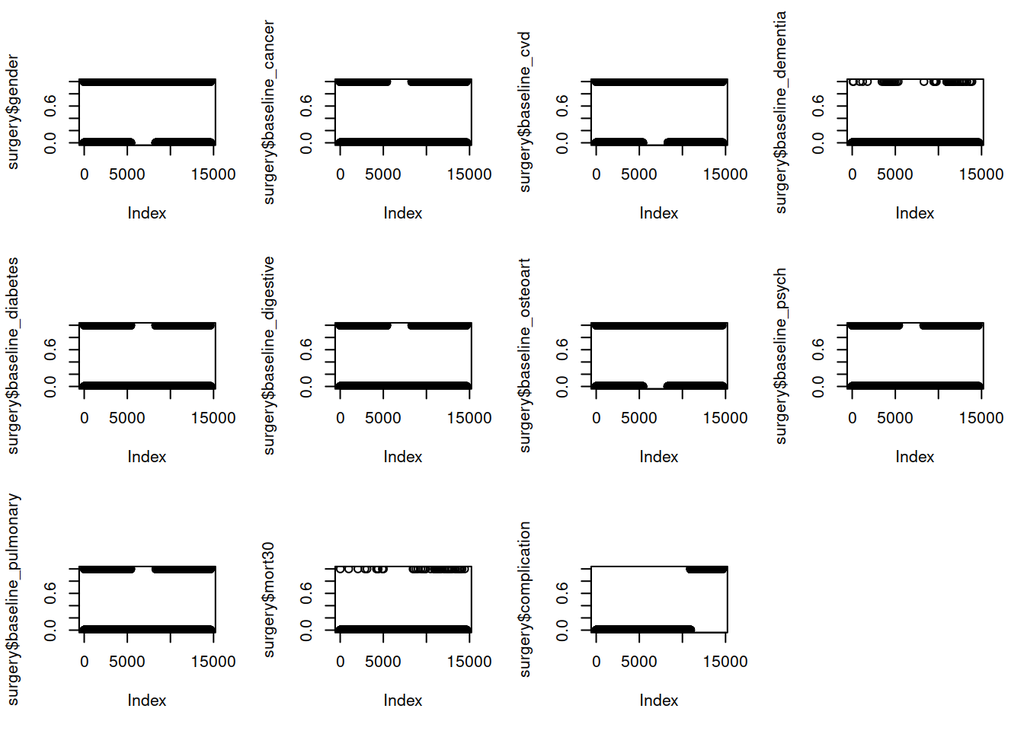

```r
par(mfrow=c(3,4))
plot(surgery$gender)
plot(surgery$baseline_cancer)
plot(surgery$baseline_cvd)
plot(surgery$baseline_dementia)
plot(surgery$baseline_diabetes)
plot(surgery$baseline_digestive)
plot(surgery$baseline_osteoart)
plot(surgery$baseline_psych)
plot(surgery$baseline_pulmonary)
plot(surgery$mort30)
plot(surgery$complication)
```

### EM Algorithm

The first algorithm that will be tried here is the simplest possible estimation method that is the EM Algorithm. This only gives points estimates of the model parameters. We will assume 2 groups of operations. After a few tries, we think that a sensible number of restarts is 20 in order to find the optimal model.

```r
fit.EM=blca.em(surgery, 2,restarts=20)
```

```
## Restart number 1, logpost = -63279.5...
## New maximum found... Restart number 2, logpost = -63279.48...
## Restart number 3, logpost = -63279.49...
## Restart number 4, logpost = -63279.49...
## Restart number 5, logpost = -63279.48...
## Restart number 6, logpost = -63279.5...
## New maximum found... Restart number 7, logpost = -63279.47...
## Restart number 8, logpost = -63279.51...
## Restart number 9, logpost = -63279.49...
## Restart number 10, logpost = -63279.48...
## Restart number 11, logpost = -63279.48...
## Restart number 12, logpost = -63279.5...
## Restart number 13, logpost = -63279.5...
## Restart number 14, logpost = -63279.52...
## Restart number 15, logpost = -63279.49...
## Restart number 16, logpost = -63279.48...
## Restart number 17, logpost = -63279.5...
## Restart number 18, logpost = -63279.5...
## Restart number 19, logpost = -63279.51...
## Restart number 20, logpost = -63279.52...
```

```r
print(fit.EM)
```

```
##
## MAP Estimates:
##
##
## Item Probabilities:
##
##         gender baseline_cancer baseline_cvd baseline_dementia baseline_diabetes
## Group 1  0.428           0.339        0.516             0.006             0.151
## Group 2  0.962           0.000        0.979             0.001             0.018
##         baseline_digestive baseline_osteoart baseline_psych baseline_pulmonary
## Group 1              0.242             0.151          0.105              0.121
## Group 2              0.009             1.000          0.004              0.002
##         mort30 complication
## Group 1  0.005        0.323
## Group 2  0.000        0.010
##
## Membership Probabilities:
##
## Group 1 Group 2
##   0.774   0.226
```

The model trained `fit.EM` has two attributes in order to get the class probabilities and the item probabilities according to the estimation.

```r
fit.EM$classprob
```

```
## [1] 0.7744048 0.2255952
```

```r
fit.EM$itemprob
```

```
##         gender baseline_cancer baseline_cvd baseline_dementia baseline_diabetes
## [1,] 0.4284476     0.338650852    0.5159040      0.0060288909        0.15084651
## [2,] 0.9623333     0.000281572    0.9786347      0.0008093331        0.01798954
##      baseline_digestive baseline_osteoart baseline_psych baseline_pulmonary
## [1,]        0.242018672         0.1512777    0.105350784        0.120852507
## [2,]        0.009420368         0.9999760    0.003639442        0.002219687
##            mort30 complication
## [1,] 0.0050591335   0.32255769
## [2,] 0.0002007352   0.01039504
```

Let us also show the estimates in a visual way:

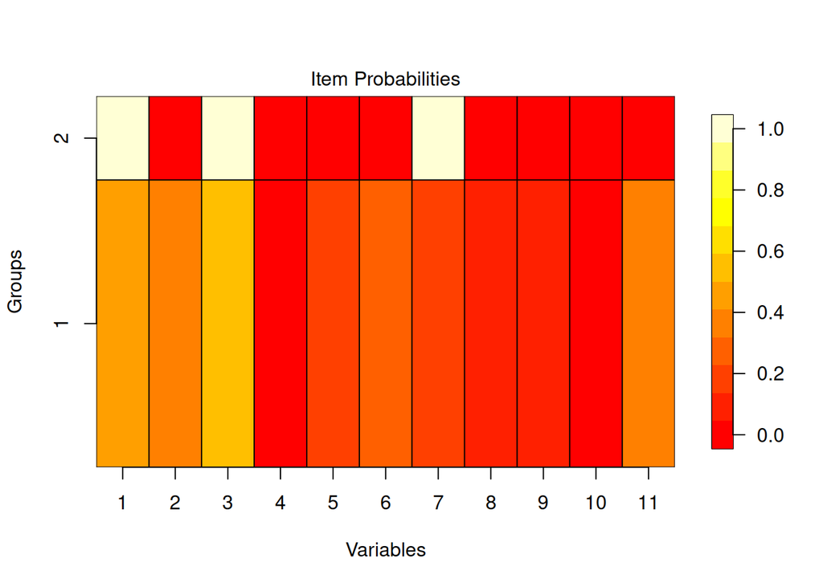

```r
plot(fit.EM)
```

With the information that has been shown, we see a considerable higher estimation of samples in group 1 being a clear differentiation between groups due to a considerable gap in the values of variables 1, 3 and 7.

### Gibbs sampling algorithm

After the *EM* algorithm, we are also going to try *Gibbs* sampling algorithm:

```r
fit.GS=blca(surgery, 2, method = "gibbs", iter=100)
```

```
## Initialising sampler...starting burn-in.
## Burn-in completed...
## Sampling run completed.
```

```r
print(fit.GS)
```

```
##
## MAP Estimates:
##
##
## Item Probabilities:
##
##         gender baseline_cancer baseline_cvd baseline_dementia baseline_diabetes
## Group 1  0.428           0.339        0.515             0.006             0.150
## Group 2  0.963           0.001        0.980             0.001             0.018
##         baseline_digestive baseline_osteoart baseline_psych baseline_pulmonary
## Group 1              0.242             0.152          0.105              0.121
## Group 2              0.009             0.999          0.003              0.002
##         mort30 complication
## Group 1  0.005        0.322
## Group 2  0.001        0.010
##
## Membership Probabilities:
##
## Group 1 Group 2
##   0.775   0.225
##
## Posterior Standard Deviation Estimates:
##
##
## Item Probabilities:
##
##         gender baseline_cancer baseline_cvd baseline_dementia baseline_diabetes
## Group 1  0.004           0.005        0.005             0.001             0.003
## Group 2  0.005           0.001        0.004             0.001             0.003
##         baseline_digestive baseline_osteoart baseline_psych baseline_pulmonary
## Group 1              0.004             0.004          0.003              0.003
## Group 2              0.002             0.001          0.002              0.001
##         mort30 complication
## Group 1  0.001        0.005
## Group 2  0.000        0.003
##
## Membership Probabilities:
##
## Group 1 Group 2
##   0.004   0.004
```

In terms of class probability with the estimation the model `fit.GS` did, we observe very similar values in this case.

The main difference when trying this method is the huge increase in the execution, with our computation power we even had to reduce the number of iterations with the attribute `iter`. On the other hand, it allows us to know the posterior standard deviation estimates. Given this, we are capable now of plotting the density estimates for the model parameters. With the attribute `which` we can select if we want the item probabilities conditional on class membership:

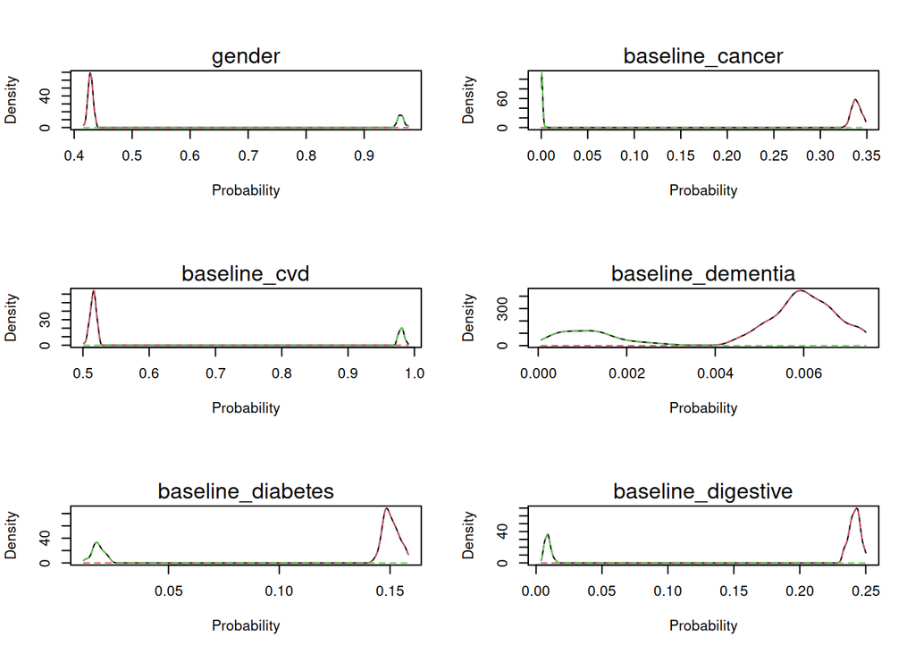

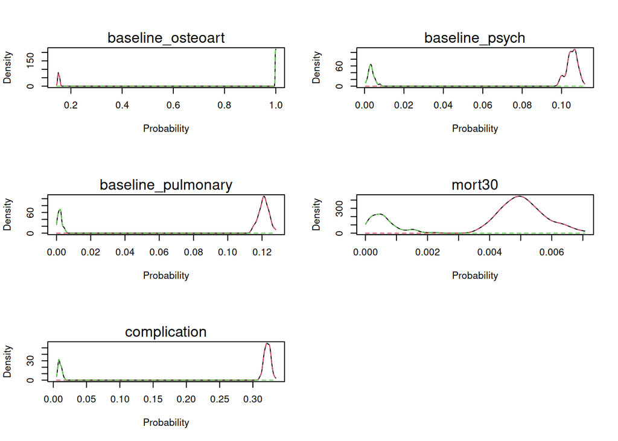

```r
par(mfrow = c(3, 2))
plot(fit.GS,which=3)
```

Or the class probabilities

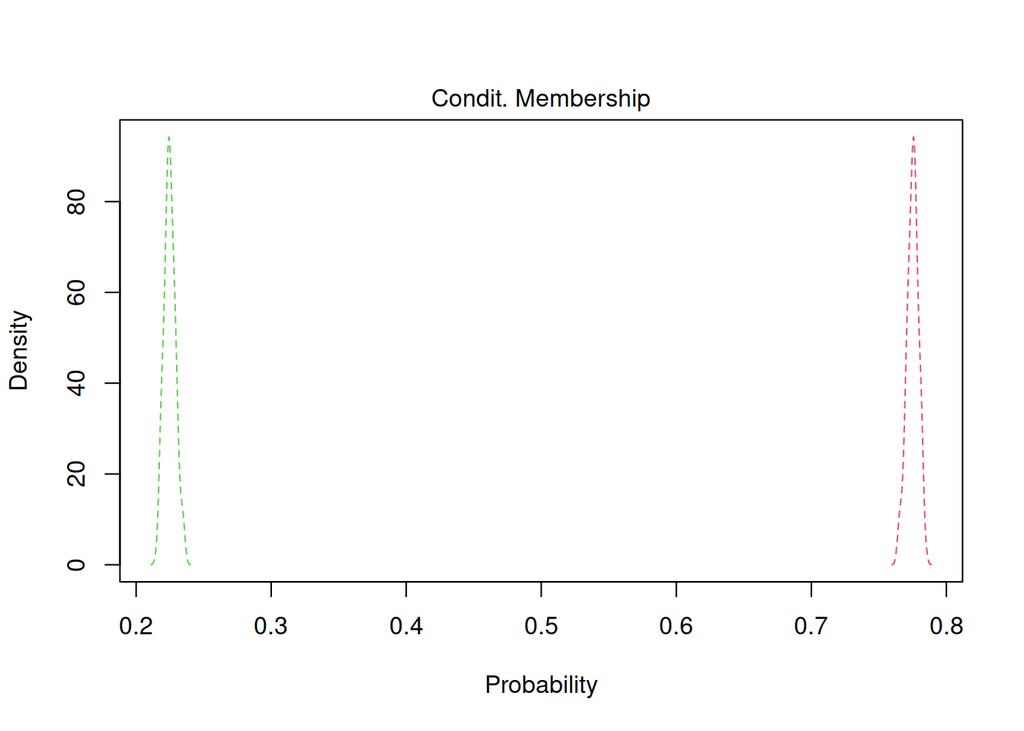

```r
par(mfrow = c(1, 1))
plot(fit.GS,which=4)
```

As we said, similar values than in the *EM* case.

### Variational Bayes

In this last part of the analysis, we will check the performance of the *Variational Bayes* method which basically consists in approximation the posterior distribution with a variational distribution, adjusting parameters using a mixture of *dirichlet*, *beta* and *multinomial* distributions. The goal is reducing Kullback-Leibler divergence between the posterior and the variational approximation.

```r
fit.VB=blca(surgery, 2, method = "vb")
```

```
## Restart number 1, logpost = -63404.16...
```

```r
print(fit.VB)
```

```
##
## MAP Estimates:
##
##
## Item Probabilities:
##
##         gender baseline_cancer baseline_cvd baseline_dementia baseline_diabetes
## Group 1  0.428           0.339        0.516             0.006             0.151
## Group 2  0.962           0.001        0.978             0.001             0.018
##         baseline_digestive baseline_osteoart baseline_psych baseline_pulmonary
## Group 1              0.242              0.15          0.105              0.121
## Group 2              0.010              1.00          0.004              0.003
##         mort30 complication
## Group 1  0.005        0.323
## Group 2  0.000        0.011
##
## Membership Probabilities:
##
## Group 1 Group 2
##   0.774   0.226
##
## Posterior Standard Deviation Estimates:
##
##
## Item Probabilities:
##
##         gender baseline_cancer baseline_cvd baseline_dementia baseline_diabetes
## Group 1  0.005           0.004        0.005             0.001             0.003
## Group 2  0.003           0.001        0.003             0.001             0.002
##         baseline_digestive baseline_osteoart baseline_psych baseline_pulmonary
## Group 1              0.004             0.003          0.003              0.003
## Group 2              0.002             0.000          0.001              0.001
##         mort30 complication
## Group 1  0.001        0.004
## Group 2  0.000        0.002
##
## Membership Probabilities:
##
## Group 1 Group 2
##   0.003   0.003
```

Luckily for us, the execution time is much smaller now, comparing it with the *Gibbs* case.

```r
fit.VB$itemprob
```

```
##         gender baseline_cancer baseline_cvd baseline_dementia baseline_diabetes
## [1,] 0.4280912    0.3388476865    0.5155173      0.0060210880        0.15090587
## [2,] 0.9615497    0.0008772973    0.9782213      0.0008555503        0.01828469
##      baseline_digestive baseline_osteoart baseline_psych baseline_pulmonary
## [1,]        0.242128952         0.1504379    0.105391912        0.120873628
## [2,]        0.009915367         0.9996644    0.003880135        0.002592145
##            mort30 complication
## [1,] 0.0050409090   0.32279201
## [2,] 0.0002812003   0.01076449
```

```r
fit.VB$classprob
```

```
## [1] 0.7735561 0.2264439
```

In terms of item and class probabilities, the results obtained are pretty much the same than in the previous cases.

We will now plot the density estimates for the item probabilities:

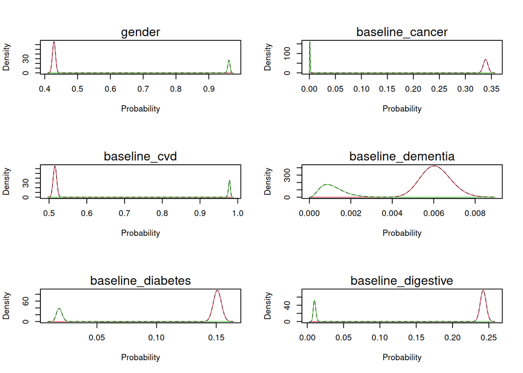

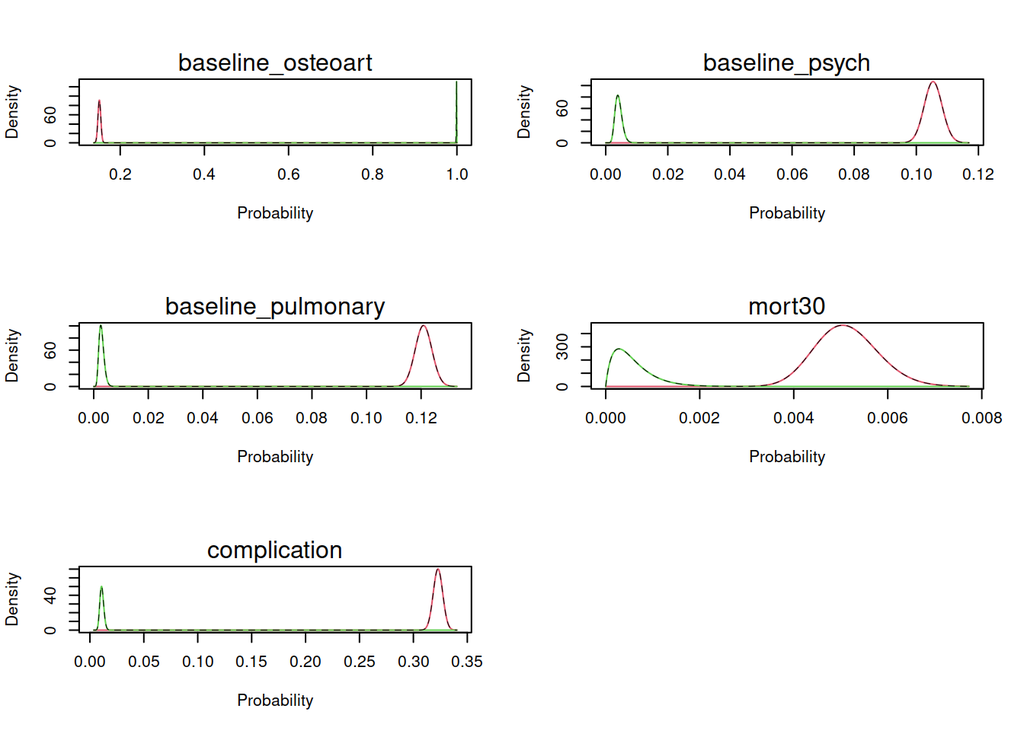

```r
par(mfrow = c(3,2))
plot(fit.VB,which=3)
```

In this item probabilities we don’t observe much difference either. Let us take a look at the class probabilities:

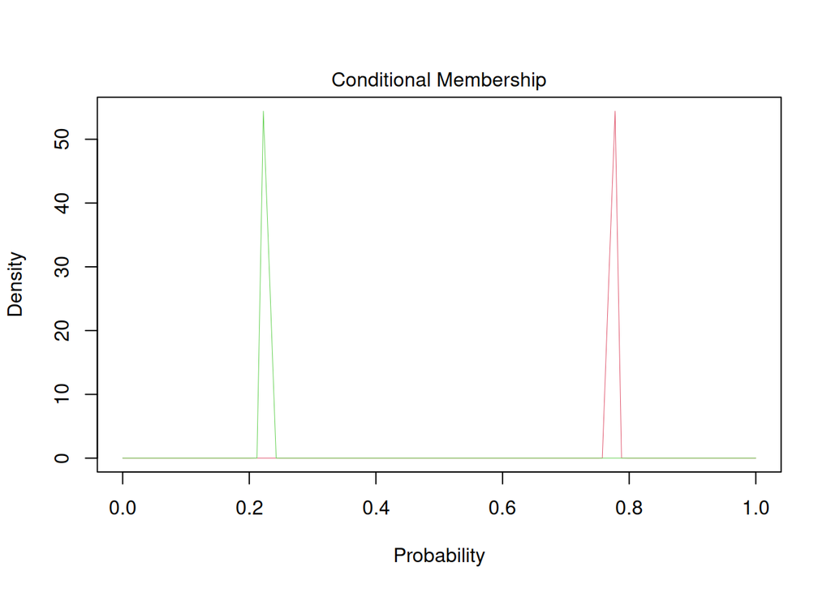

```r
par(mfrow = c(1,1))
plot(fit.VB,which=4)
```

## Conclusion

We studied three different methods for performing bayesian clustering that may be useful as a first step in some data analytics problems which may be present to us in the future.

A good practice would be using the variational algorithm in a first place in order to be able to try different attributes in a reduced time. Then, we can explore other methods to compare the results.